# Getting Started with AWS

## *What is AWS?*

Companies used to host and maintain hardware (compute, storage, and networking equipment) in their own data centers. They needed to allocate entire infrastructure departments to take care of them, resulting in a costly operation that made some workloads and experimentation impossible.

Along with the internet growth, the need for more hardware also grew. This resulted in an increasing cost of maintaining a large physical presence. To solve this cloud computing was invented.

**Cloud computing is the on-demand delivery of IT resources over the internet with pay-as-you-go pricing.** You no longer have to manage and maintain your own hardware in your own data centers. Companies like AWS own and maintain these data centers and provide virtualized data center technologies and services to users over the internet.

An important advantage of cloud computing is that with it you can ease the testing and deployment of applications, making it much easier to manage the quality assurance (QA) environment that has the exact same configurations as production, making the time-to-market decrease. This results in an elimination of the repetitive common tasks that don't differentiate your business (*e.g.* installing virtual machines, storing backups, etc.), that let you focus on what is strategically unique to your business and let AWS handle the tasks that are time consuming and don't separate you from your competitors.

AWS provides cloud computing services (the IT resources mentioned in the clod computing definition). With AWS we will architect a scalable, highly available, and cost effective infrastructure to host our applications.

### The Six Benefits of Cloud Computing

1. **Pay as you go**: instead of investing in data centers and hardware before you know how you are going to use them, you pay only when you use computing resources, and pay only for how much you use.
2. **Massive economies of scale**: by using cloud computing, you can achieve a lower cost than you can get on your own. Because usage from hundreds of thousands of customers is aggregated in the cloud, AWS can achieve higher economies of scale, which translates into lower pays as you go prices.
3. **Stop guessing capacity**: you don't need to guess on your infrastructure capacity needs. This guessing process often end up in either sitting on expensive idle resources or dealing with limited capacity. With cloud computing you scale as you need.
4. **Increase speed and agility**: because of the availability of IT resources with cloud computing, making scalable use of resources is fast. This results in an increase of agility for the organization since the cost and time it takes to experiment and develop is significantly lower.
5. **Stop spending money running and maintaining data centers**: this let you focus in differentiate your business, not the infrastructure.
6. **Go global in minutes**: with cloud computing it is easy to deploy your application in multiple regions around the world with just a few clicks. This means you can provide lower latency and a better experience for you customers at a minimal cost.

### Links

- [What is cloud computing?](https://aws.amazon.com/what-is-cloud-computing/)
- [Types of cloud computing](http://docs.aws.amazon.com/whitepapers/latest/aws-overview/types-of-cloud-computing.html)
- [Cloud computing with AWS](https://aws.amazon.com/what-is-aws/)

## *AWS Global Infrastructure*

Infrastructure exists as the foundation of every cloud application. In AWS, this physical infrastructure makes up the AWS Global Infrastructure, in the form of Availability Zones and Regions.

[figure not shown]

*Regions* are geographic locations worldwide where AWS hosts its data centers. AWS Regions are names after the locations they reside. AWS Regions are independent from one another. This means that your data is not replicated from one Region to another, without your explicit consent and authorization.

Inside every Region is a cluster of Availability Zones (AZ). An AZ consists of one or more data centers with redundant power, networking, and connectivity. These data centers operate in discrete facilities with undisclosed locations.

### Choose the Right AWS Region

There are four main aspects when deciding which AWS Region to host your application and workloads:

- **Latency**: if your application is sensitive to latency, choose a Region that is close to your user base. This helps prevent long wait times for your customers. Synchronous applications such as gaming, telephony, WebSockets, and IoT are significantly affected by higher latency. Some asynchronous applications can suffer from an impact on user connectivity.
- **Price**: due to the local economy and the physical nature of operating data centers, prices may vary from one Region to another. The pricing in a Region can be impacted by internet connectivity, prices of imported pieces of equipment, customs, real state, and more. Instead of charging a flat rate worldwide, AWS charges based on the financial factors specific to the location.
- **Service availability**: some services may not be available in some Regions. The AWS documentation provides a table containing the Regions and the available services within each one.
- **Data compliance**: enterprise companies often need to comply with regulations that require customers data to be stored in a specific geographic territory.

### Scope AWS Services and Resiliency

Depending on the AWS Service you use, your resources are either deployed at the AZ, Region, or Global level. Each service is different, so you need to understand how the scope of a service may affect your application architecture.

A Region-scoped service AWS automatically performs actions to increase data durability and availability. To keep an application available, you need to maintain high availability and resiliency. A well-known best practice for cloud architecture is to use Region-scoped managed services. These services come with availability and resiliency built in.

## *Interacting with AWS*

Every action you make in AWS is an API call that is authenticated and authorized. In AWS, you can make API calls to services and resources through the AWS Management Console, the AWS Command Line Interface (CLI), or the AWS Software Development Kits (SDKs).

### [The AWS Management Console](https://docs.aws.amazon.com/awsconsolehelpdocs/latest/gsg/getting-started.html)

This is one way to manage cloud resources, where you log in and click on the desired service. This can be the easiest way to create and manage resources when you are starting.

[figure not shown]

The services are placed in categories, such as Compute, Containers, Machine Learning. On the upper right corner you can chose the Region.

### [The AWS Command Line (CLI)](https://aws.amazon.com/cli/)

When you're more advances, and have to manage more resources programmatically, instead of doing this manually in the AWS Management Console, you can schedule and AWS CLI script with an API call to do the process for you. The AWS CLI is a unified tool to manage AWS services. With this tool to download and configure, you control multiple AWS services from the command line and automate them with scripts.

The AWS CLI is open-source, and there are installers available for Windows, Linux and Max OS.

### [AWS Software Development Kits (SDKs)](https://aws.amazon.com/tools/)

API calls to AWS can also be performed by executing code with programming languages. You can do this by using AWS SDKs, which are open-source and maintained by AWS for the most popular programming languages such as C++, Go, Java, Python, etc.

Developers commonly use AWS SDKs to integrate their application source code with AWS services. Below you can see an example of the Python AWS SDK:

```
import boto3
ec2 = boto3.client('ec2')
response = ec2.describe_instances()
print(reponse)
```

# Security in the AWS Cloud

## *Security and the AWS Shared Responsibility Model*

Managing security and compliance is a shared responsibility between AWS and you. AWS has created the *shared responsibility model*, where there is the distinction of *security of the cloud* and *security in the cloud*.

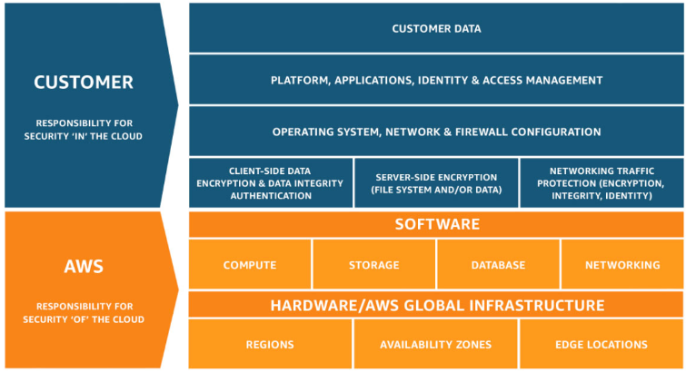

AWS is responsible for security of the cloud. This means AWS is required to protect and secure the infrastructure that runs all the services offered in the AWS Cloud (AWS Regions, AZs, data centers, hardware, software, networking, etc.). The level of responsibility AWS has depends on the service. AWS classifies services into three different categories:

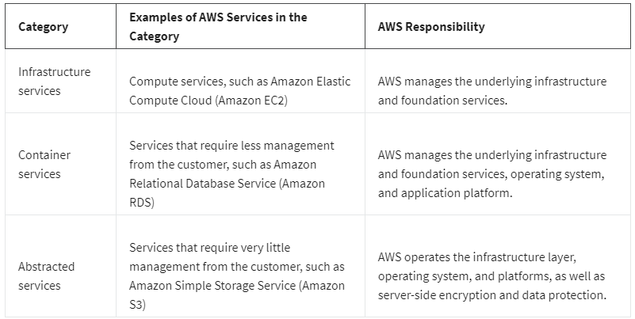

The customer is responsible for security in the cloud. When using AWS you're responsible for properly configuring the service and your applications, as well as ensuring your data is secure. The level of responsibility depends on the service. Some services require you to perform all the necessary security configuration and management tasks, while other more abstracted services require you to only manage the data an control access to your resources.

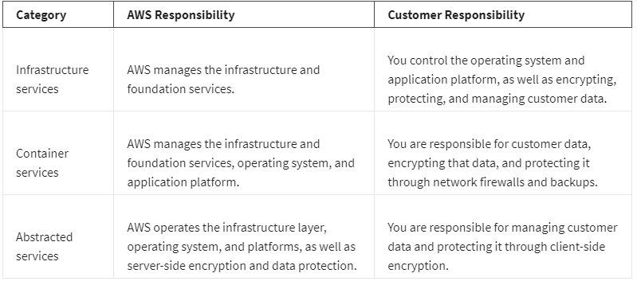

This results in the necessity of reviewing the level of responsibility required to secure the services you use. It{s also important to review how the shared security model aligns with the security standards in your IT environment, as well as any applicable laws and regulations.

## *Protect the AWS Root User*

When you create your AWS account, you use a combination of an email address and a password to verify your identity. If the user types in the correct email and password, the systems assumes the user is allowed to enter and grants them access. This is the process of *authentication*. Authentication ensures that the user is who they say they are. Usernames and passwords are the most common types of authentication, but you may also work with other forms, such as token-based authentication or biometric data like a fingerprint.

*Authorization* is the process of giving users permission to access AWS resources and services. Authorization determines whether the user can perform an action.

The identity you use to sign-in to AWS is the **AWS root user** and is accessed by signing in with the email address and password that you used to create the account. The AWS root user has two sets of credentials associated with it. One is the email address and password used to create the account. This allows you to access the AWS Management Console. The second set is called access keys, which allow you to make programmatic requests from the AWS CLO or AWS API.

### Best Practices When Working with the AWS Root User

Keep in mind that the root user has complete access to all AWS services and resources in your account, as well as your billing and personal information. Due to this, securely lock away the credentials associated with the root user and do not use the root user for everyday tasks.

To ensure the safety of the root user:

- Choose a strong password for the root user.
- Never share your root user password or access keys with anyone.
- Disable or delete the access keys associated with the root user.
- Do not use the root user for administrative tasks or everyday tasks.

### Resources

- [Enabling a Hardware MFA Device (Console)](https://docs.aws.amazon.com/IAM/latest/UserGuide/id_credentials_mfa_enable_physical.html)
- [Enabling a U2F Security Key (console](https://docs.aws.amazon.com/IAM/latest/UserGuide/id_credentials_mfa_enable_u2f.html)
- [Enabling a Virtual Multi-Factor Authentication (MFA) Device (console)](https://docs.aws.amazon.com/IAM/latest/UserGuide/id_credentials_mfa_enable_virtual.html)
- [Table of supported MFA devices](https://aws.amazon.com/iam/features/mfa/)

# AWS Identity and Access Management

## *Introduction to AWS Identity and Access Management*

The application we'll design in this course is represented in the following diagram:

[figure not shown]

There are many places in the diagram where we can identify the need of access control. First we know we will need app level access control. Then we need access control for reading and writing data between the virtual machine in EC2 and Amazon S3. All API calls must be signed and authenticated.

To build this architecture you'll also have access to the AWS account. With it you will be able to create a network, launch EC2 instances and create the resources that host and run the solution in AWS. The **root user** has the permissions to do this, but you don't want to be using the root user to administer your AWS resources.

Also, if you are not the only one building the application. It is possible that in one AWS account there will be working many people. Different persons will be responsible for different parts of the architecture, and thus will need different permissions. You shouldn't give each person the root user's credentials; instead you should give them unique credentials to each person. This is where the **AWS Identity and Access Management (IAM)** comes in.

IAM is a web service that enables you to manage access to your AWS account and resources. It also provides a centralized view of who and what are allowed inside your AWS account (authentication), and who and what have permissions to use and work with your AWS resources (authorization).

With IAM you can share access to an AWS account and resources without having to share your set of access keys or password. You can also provide granular access to those working in your account, so that people and services only have permissions to the resources they need.

- IAM is global and not specific to any one Region. This means you can see and use your IAM configurations from any Region in the AWS Management Console.
- IAM is integrated with many AWS services by default.
- You can establish password policies in IAM to specify complexity requirements and mandatory rotation periods for users.
- IAM supports MFA.
- IAM supports identity federation, which allows users who already have passwords elsewhere—for example, in your corporate network or with an internet identity provider—to get temporary access to your AWS account.
- Any AWS customer can use IAM; the service is offered at no additional charge.

### What is an AIM User?

An IAM user represents a person or service that interacts with AWS. You define the user within your AWS account. Any activity done by that user is billed to your account. Once you create a user, that user can sign in to gain access to the AWS resources inside your account.

You can also add more users to your account as needed. Each person working in a project can have their own login credentials, preventing the sharing of them.

### IAM User Credentials

An IAM user consists of a name and a set of credentials. When creating a user, you can choose to provide the user:

- Access to the AWS Management Console
- Programmatic access to the AWS Command Line Interface (AWS CLI) and AWS Application Programming Interface (AWS API)

To access the AWS Management Console, provide the users with a user name and password. For programmatic access, AWS generates a set of access keys that can be used with the AWS CLI and AWS API. IAM user credentials are considered permanent, in that they stay with the user until there's forced rotation by admins.

When you create an IAM user you have the option to grant permissions directly at the user level. However, as the number of users helping you build your solution on AWS increases, it becomes more complicated to keep up with permissions. For this, you could cluster users into groups and grant permissions at a group level.

### What is an IAM Group?

An IAM groups is a collection of users. All users in the group inherit the permissions assigned to the group. This makes it easy to give permissions to multiple users at once. It's a more convenient and scalable way of managing permissions for users in your AWS account. These are the features of groups:

- Groups can have many users
- Users can belong to many groups
- Groups cannot belong to groups

The root user can perform all actions on all resources inside an AWS by default. This is in contrast to creating new IAM users, new groups, or new roles. New IAM identities can perform no actions inside our AWS account by default until you explicitly gran them permission. **The way you grant permissions in IAM is by using IAM policies**.

### IAM Policy

To manage access and provide permissions to AWS services and resources, your create IAM policies and attach them to IAM users, groups, and roles. Whenever an user makes a request, AWS evaluates the policies associated with them, to determine whether to allow or deny the request.

Most policies are in JSON documents with several policy elements. Each policy has major elements:

- **Version**: defines the version of the policy language. It specifies the language syntax rules that are needed by AWS to process a policy.
- **Effect**: specifies whether the statement will allow or deny access.
- **Action**: describes the type of action that should be allowed or denied
- **Resource**: specifies the object or objects that the policy statement covers

- [IAM Identities](https://docs.amazonaws.cn/en_us/IAM/latest/UserGuide/id.html)
- [Access Management with AWS IAM](https://docs.amazonaws.cn/en_us/IAM/latest/UserGuide/id.html)

## *Role Based Access in AWS*

We have seen that policies can be applied to AWS identities, we've seen that for users and groups. They can also be applied to IAM roles. **An IAM role is an identity that can be assumed by someone or something who needs temporary access to AWS credentials**. Most AWS API calls must be signed and authenticated.

IAM roles have assigned credentials used to sign AWS API calls; however roles don't have static login credentials (*i.e.* user name and password), they are assumed programmatically, are temporary for a configurable amount of time, and expire and are rotated.

AWS uses roles for communicating different services used for an application. Another identity that can assume an IAM role to gain access to AWS is external identity providers. For example, let's say you have a business that employs 5000 employees and they all need access to an AWS account. You already have an identity provider in place that allows these employees to log into their laptops and access various corporate resources. You don't need to create 5000 IAM users for each employee. Instead you can leverage IAM roles ot grant access to existing identities from your enterprise directory. These are known as federated users. AWS assigns a role to a federated user when access is requested through an identity provider. AWS has services that can make this process easier, such as AWS Single Sign-On (SSN).

## *IAM Best Practices*

1. **Lock down the AWS root user**: the root user is an all-powerful and all-knowing identity within your AWS account. If a malicious user were to gain control of root-user credentials, they would be able to access every resource within your account, including personal and billing information. To lock down the root user:
   - Don't share the credentials associated with the root user
   - Consider deleting the root user access keys
   - Enable MFA on the root account
2. **Follow the principle of less privilege**: least privilege is a standard security principle that advises you to grant only the necessary premissions to do a particular job and nothing more. To implement least privilege for access control, start with the minimum set of permissions in an IAM policy and then grant additional permssions as necessary for a user, group or role.
3. **Use IAM appropriately**: IAM is used to secure access to your AWS account and resources. It simply provides a way to create and manage users, groups, and roles to access resources within a single AWS account. IAM is **not** used for website authentication and authorization, such as providing users of a website with sign-in and sign-up functionality. IAM also does **not** support security controls for protecting operating systems and networks.
4. **Use IAM roles when possible**: maintaining roles is easier than maintaining users. When you assume a role, IAM dynamically provides temporary credentials that expire after a defined period of time, between 15 minutes and 36 hours. Users, on the other hand, have long-term credentials in the form of user name and password combinations or a set of access keys. User access keys only expire when you or the admin of your account rotates these keys. User login credentials expire of you have applied a password policy to your account that forces users to rotate their password.
5. **Consider using an identity provider**: if you decide to make an application that needs a handful of people working on it, consider managing employee identity information through an identity provider (IdP). Using an IdP, whether it be an AWS service such as AWS SSO or a third-party provider, provides yo a single source of truth for all identities in your organization. You no longer have to create separate IAM users in AWS. You can instead use IAM roles to provide permissions to identities that are federated from your IdP.
6. **Consider AWS SSO**: if you have an organization that spans many employees and multiple AWS accounts, you may want your employees to sign in with a single credential. AWS SSO is an IdP that lets your users sign in to a user portal with a single set of credentials. It then provides them access to all their assigned accounts and applications in one central location. AWS SSO is similar to IAM, in that it offers a directory where you can create users, organize them in groups, and set permissions across those groups, and grant access to AWS resources. However, AWS SSO has some advantages over IAM (*e.g.* if you're a third-party IdP, you can sync your users and groups to AWS SSO). This removes the burden of having to re-create users that already exist elsewhere, and it enables you to manage those users from your IdP. More importantly, AWS SSO separates the duties between your IdP and AWS, ensuring that your cloud access management is not inside or depend on your IdP.

### Link to Lab 2

https://aws-tc-largeobjects.s3-us-west-2.amazonaws.com/DEV-AWS-MO-GCNv2/lab-2-iam.html

# *Compute as a Service on AWS*

To avoid the hassle of having to research, buy, wait for the delivery and maintain the compute hardware, AWS takes care of the harder part building and securing data centers. It also bought, racked and stacked them, and made them online, ready to be used.

EC2 provides virtual machines with a wide variety of capabilities, priced accordingly, that are at the disposal of the user, in just few minutes.

### Understanding Servers

The first building block you need to host an application is a server. Servers often times can handle Hypertext Transfer Protocol (HTTP) requests and send responses to clients following the client-server model, though any API based communication also falls under this model. A client being a person or computer that sends a request, and a server handling the requests is a computer, or collection of computers, connected to the internet serving websites to the internet users.

These servers power your application by providing CPU, memory, and networking capacity to process users' requests and transform them into responses. For context, common HTTP servers include:

- Windows options, such as Internet Information Services (IIS).
- Linux options, such as Apache HTTP Web Server, Nginx, and Apache Tomcat.

To run an HTTP server on AWS, you need to find a service that provides compute power in the AWS Management Console. At a fundamental level, there are three types of compute options: virtual machines, container services, and serverless. Virtual machines emulate a physical server and allows you to install an HTTP server to run your application. To run these virtual machines, you install a hypervisor on a host machine. This hypervisor provisions the resources to create and run your virtual machines.

Some AWS compute services use Amazon EC2 or use virtualization concepts under the hood, therefore it is best to understand this service first before moving on to container services and serverless compute.

## *Elastic Compute Cloud*

EC2 instances give you a lot of flexibility and control in the cloud, where you can configure them to meet your needs. You can provision one or may EC2 instances easily. At the end of the billing cycle, you only pay for what you use (per second or per hour), depending on the type of instance.

EC2 is a web service that provides secure, resizable compute capacity in the cloud. It allows to provision virtual servers called EC2 instances. You can create and manange these instances through the AWS Management Console, the AWS Command Line Interface (CLI) and the AWS Software Development Kits (SDKs).

In order to create an EC2 instance you need to define:

- Hardware specifications (CPU, memory, network, storage)
- Logical configurations (networking location, firewall rules, authentication, operating system)

When launching an EC2 instance, the first setting you configure is which operating system you want by selecting an Amazon Machine Image (AMI).

In AWS, instead of spinning up a server (installing an operating system) this is taken care by AWS through the AMI you choose. The AMI let you configure your operating system, select storage mappings, the architecture type (32-bit, 64-bit or 64-bit ARM), and additional software installed.

EC2 instances are live instatiations of what is defined in an AMI: the AMI is how you model and define your instance, while the EC2 instance is the entity you interact with, where you can install your web server, and serve your content to users. When you launch anew instance AWS allocates a virtual machine that runs on a hypervisor. Then the AMI you selected is copied to the root device volume, which contains the image used to boot the volume. In the end, you get a server you can connect to and install packages and any additional software.

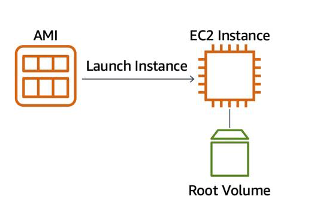

AMIs are reusable. If you want to create a second EC2 instance with the same configurations, by creating a new AMI from your running instance and use this AMI to start a new instance. This way, your new instance will have all the same configurations as your current instance, because the configurations set in the AMIs are the same.

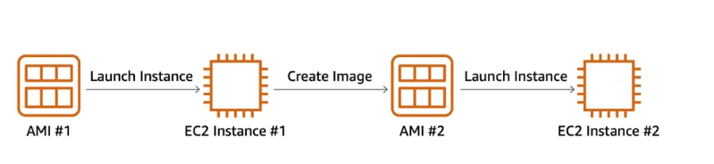

### What Makes Up an EC2 Instance?

EC2 instances are combinations of virtual processors (vCPUs), memory, network, and in some cases, instance storage and graphics processing units (GPUs). When you create an EC2 instance, you need to choose how much you need of each of these components.

AWS offers a variety of instances that differ based on performance. To get an overview of the capacity details for a particular instance, you should look at the instance type. **Instance types consist of a prefix identifying the type of workloads they're optimized for, followed by a size**. For example, the instance type `c5.large` can be broken down into the following elements:

- **`c5`** determines the instance family and generation number. Here, the instance belongs to the fifth generation of instances in an instance family that's optimized for generic computation.
- **`large`** determines the amount of instance capacity.

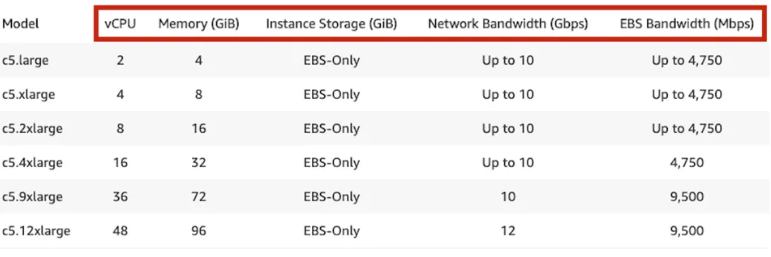

### What Are Instance Families?

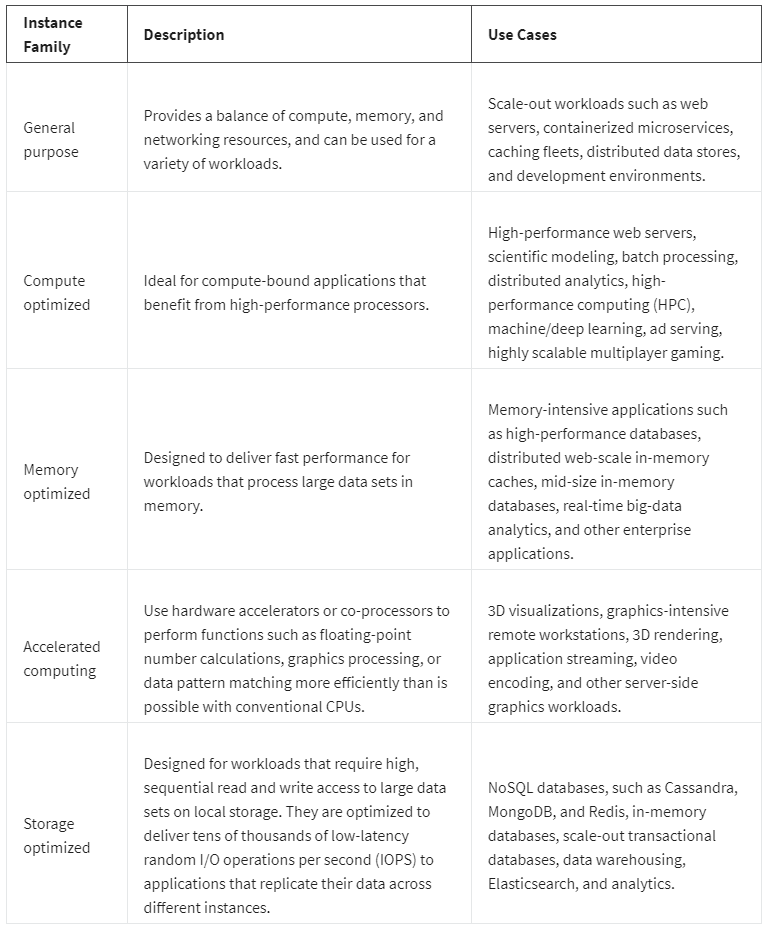

### Architect for High Availability

Your instance resides in an Availability Zone of your choice. As we've seen AWS services that are scoped at the Availability Zone level must be architected with high availability in mind. **When architecting any application for high availability, consider using at least two EC2 instances in two separate Availability Zones**.

## *Amazon EC2 Instance Lifecycle*

An EC2 instance transitions between different states from the moment you create it all the way through to its termination:

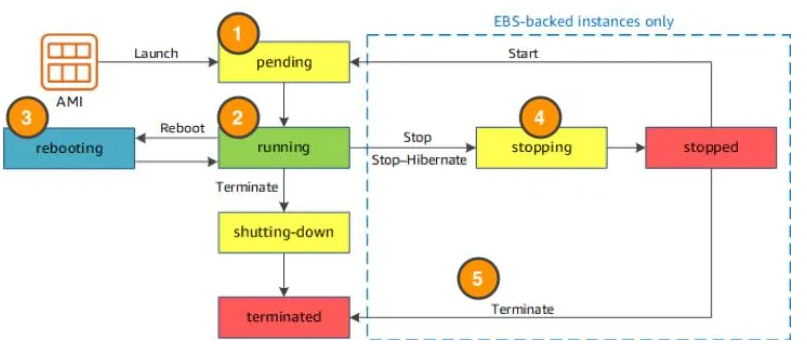

When you launch an instance it enters the *pending* state (1). When the instance is pending, billing has not started. At this stage, the instance is preparing to enter the running state. Pending is where AWS performs all actions needed to set up an instance, such as copying the AMI content to the root device and allocating the necessary networking.

When your instance is *running* (2), it's ready to use, This is also the stage where billing begins. As soon as an instance is running, you are then able to take other action on the instance, such as *reboot, terminate, stop*, and *stop-hibernate*.

When you *reboot* an instance (3), it's different than performing a stop action and then a start action. Rebooting an instance is equivalent to rebooting an operating system. The instance remains on the same host computer and maintains its public and private IP address, and any data on its instance store. It typically takes a few minutes for the reboot to complete.

When you stop and start an instance (4), your instance may be placed on a new underlying physical server. Therefore, you lose any data on the instance store that were on the previous host computer. When you stop an instance, the instance gets a new public IP address but maintains the same private IP address.

When you *terminate* an instance (5), the instance store are erased, and you lose both the public IP address and private IP address of the machine. Termination of an instance means you can no longer access the machine.

### Difference Between Stop and Stop-Hibernate

When you stop your instance, it enters the stopping state, and then the stopped state. AWS does not charge usage or data transfer fees for your instance after you stop it, but storage for any Amazon EBS volumes is still charged. While your instance is in the stopped state, you can modify some attributes, like the instance type. When you stop your instance, the data stored in memory (RAM) is lost.

When you stop-hibernate your instance, AWS signals the operating system to perform hibernation (suspend-to-disk), which saves the contents from the instance memory (RAM) to the Amazon EBS root volume.

Consider a scenario where you build a standard three tier application, where you have web servers, application servers and database servers. Turns out, the application you built becomes extremely popular. To relieve some stress on the database that supports your application, you want to implement a custom backend layer that caches database information in memory (RAM). You decide to run this custom backend caching solution on Amazon EC2.

In this scenario, the stop-hibernate feature would be instrumental in persisting storage. It would prevent you from having to manually create scripts to save this RAM data before shutting down the server.

### What Makes Up the Pricing?

To understand EC2 pricing, let’s decouple the instance price from other services attached to it, such as storage and networking costs. In this unit we refer to the instance cost as the cost associated with the instance in terms of specifications and not the total blended cost of running an instance.

Once an instance is launched in your AWS account, the billing usually accrues on a per-second basis. For simplicity of calculation, prices are stated per-hour. For example, if you have an instance running for 5 minutes and 38 seconds during a given month, you only pay for 338 seconds of utilization at the end of the month.

One exception to this pricing convention may be third-party AMIs purchased from the AWS Marketplace, which may have a minimum billing of 1 hour.

### What Are the EC2 Pricing Options?

One of the ways to reduce costs with Amazon EC2 is to choose the right pricing option for the way your applications run. There are three main purchasing options for EC2 instances: on-demand, reserved, and spot instances.

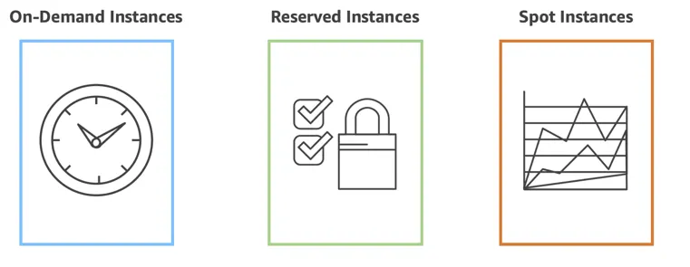

With *On-Demand* instances, you pay for compute capacity with no long-term commitments. Billing begins whenever the instance is running, and billing stops when the instance is in a stopped or terminated state. The price per second for a running On-Demand instance is fixed.

For applications that require servers to be running all the time, you are less likely to benefit from the On-Demand pricing model, simply because there is no situation where you will need to turn servers off. For example, you might want the web server hosting the frontend of your corporate directory application to be running 24/7 so that users can access the website at any time. Even if there are no users connected to your website, you don’t want to shut down the servers supporting the site in case of potential user activity.

In the case when servers cannot be stopped, consider using a *Reserved Instance (RI)* to save on costs.

RIs provide you with a significant discount compared to On-Demand instance pricing. RIs provide a discounted hourly rate and an optional capacity reservation for EC2 instances. You can choose between three payment options: All Upfront, Partial Upfront, or No Upfront. You can select either a 1-year or 3-year term for each of these options. Depending on which option you choose, you are discounted differently.

- All Upfront offers a higher discount than Partial Upfront instances.
- Partial Upfront instances offer a higher discount than No Upfront.
- No Upfront offers a higher discount than On-Demand.

On-Demand and No Upfront are similar since both do not require any upfront payment. However, there is a major difference. When you choose an On-Demand instance, you stop paying for the instance when you stop or terminate the instance. When you stop an RI, you still pay for it because you committed to a 1-year or 3-year term.

Reserved Instances are associated with an instance type and an Availability Zone depending on how you reserve it. The discount applied by a Reserved Instance purchase is not directly associated with a specific instance ID, but with an instance type.

Another way of paying for EC2 instances is by using *Spot Instances*. Amazon EC2 Spot Instances allow you to take advantage of unused EC2 capacity in the AWS Cloud. They are available at up to a 90% discount compared to On-Demand prices.

With Spot Instances, you set a limit on how much you would like to pay for the instance hour. This is compared against the current Spot price that AWS determines. If the amount you pay is more than the current Spot price and there is capacity, then you will receive an instance. While they are very promising from the billing perspective, there are some architectural considerations you will need to consider in order to use them effectively.

One consideration is that your spot instance may be interrupted. For example, if AWS determines that capacity is no longer available for a particular spot instance or if the Spot price exceeds how much you are willing to pay, AWS will give you a 2-minute warning before it interrupts your instance. That means any application or workload that runs on a Spot instance must be able to be interrupted.

Because of this unique consideration, inherently fault-tolerant workloads are typically good candidates to use with Spot instances. These include big data, containerized workloads, continuous integration/continuous delivery (CI/CD), web servers, high-performance computing (HPC), image and media rendering, or other test and development workloads

## *Container Services on AWS*

AWS offers a broad spectrum of compute offerings that give you the flexibility to choose the right tool for the right job. The three main categories of compute are *virtual machines*, *containers*, and *serverless*. There is no one-size-fits-all service because it depends on your needs.

### What Is a Container?

A **container** is a standardized unit that packages up your code and all of its dependencies. This package is designed to run reliably on any platform, because the container creates its own independent environment. This makes it easy to carry workloads from one place to another, such as from development to production or form on-premises to the cloud.

### What Is a Docker?

**Docker** is a popular container runtime that simplifies the management of the entire operating system stack needed for the container isolation, including networking and storage. Docker makes it easy to create, package, deploy and run containers.

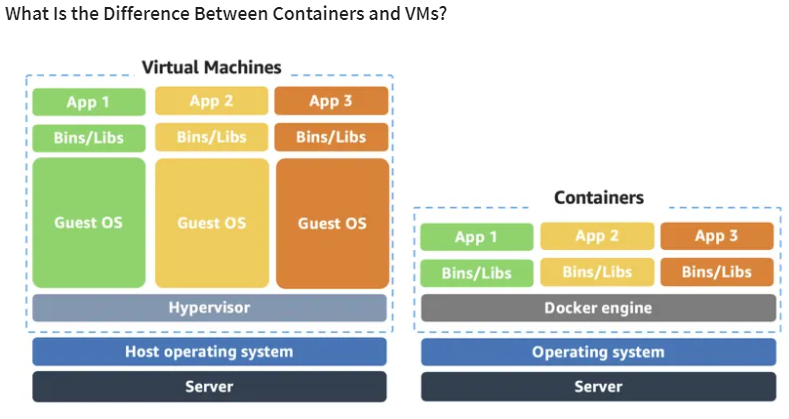

Containers share the same operating system and kernel as the host they exist on, whereas virtual machines contain their operating system. Since each virtual machine has to maintain a copy of an operating system, there's a degree of wasted space.

A container is more lightweight. They spin up quicker, almost instantly. This difference in startup time becomes instrumental when designing applications that need to scale quickly during input/output (I/O) busts. While containers can provide speed, virtual machines offer you the full strength of an operating system and offer more resources, like package installation, a dedicated kernel, and more.

### Orchestrate Containers

In AWS, containers run on EC2 instances. For example, you may have a large instance and run a few containers on that instance. While running one instance is easy to manage, it lacks high availability and scalability. Most companies and organizations run many containers on many EC2 instances across several Availability Zones.

If you're trying to manage your compute at a large scale, you need to know:

- How to place your containers in your instances.
- What happens if your container fails.
- What happens if your instance fails.
- How to monitor deployments of your containers.

This coordination is handled by a container orchestration service. AWS offers two container orchestration services: **Amazon Elastic Container Service (ECS)** and **Amazon Elastic Kubernetes Service (EKS)**.

### Amazon Elastic Container Service (ECS) And Amazon Elastic Jebernetes Service (EKS)

**Amazon ECS** is an end-to-end container orchestration service that allows you to quickly spin up new containers and manage them across a cluster of EC2 instances. To run and manage your containers, you need to install the ECS Container Agent on your EC2 instances. This agent is open source and responsible for communicating back to the Amazon ECS service about cluster management details.

Once the Amazon ECS container instances are up and running, you can perform actions that include, but are not limited to, launching and stopping containers, getting cluster state, scaling in and out, scheduling the placement of containers across your cluster, assigning permissions, and meeting availability requirements.

To prepare your application to run on Amazon ECS, you create a task definition. The task definition is a text file, in JSON format, that describes one or more containers. A task definition is similar to a blueprint that describes the resources you need to run that container, such as CPU, memory, ports, images, storage, and networking information.

**Kubernetes** is a portable, extensible, open source platform for managing containerized workloads and services. By bringing software development and operations together by design, Kubernetes created a rapidly growing ecosystem that is very popular and well established in the market.

If you already use Kubernetes, you can use Amazon EKS to orchestrate these workloads in the AWS Cloud.

- Amazon EKS is conceptually similar to Amazon ECS, but there are some differences.
- An EC2 instance with the ECS Agent installed and configured is called a container instance. In Amazon EKS, it is called a worker node.
- An ECS Container is called a task. In the Amazon EKS ecosystem, it is called a pod.
- While Amazon ECS runs on AWS native technology, Amazon EKS runs on top of Kubernetes.

If you have containers running on Kubernetes and want an advanced orchestration solution that can provide simplicity, high availability, and fine-grained control over your infrastructure, Amazon EKS is the tool for you.

## *What is Serverless?*

**Serverless** means that you can not see or access the underlying infrastructure or instances that are hosting your solutions. Instead,, the management of the underlying environment from a provisioning, scaling, fault-tolerance and maintenance perspective is taken care of for you. All you need to do is focus on your application. The rest is abstracted from you. This results in a very convenient tool. This reduces the number of operational support processes that you need to have in place. In summary the benefits of serverless are:

- No servers to provision or manage
- Scales with usage
- You never pay for idle resources
- Availability and fault tolerance built-in

This means that you now don't have to path the operating system and security updates as they are released. With serverless offerings, the line between what your are responsible versus what AWS is responsible for moves up. You don't have to access to the underlying operating system that is running the service. However, you are still responsible for thing like data encryption and access management.

**AWS Fargate** is a serverless compute platform that you can run either ECS or EKS on top of.This results in you running your containers on a managed serverless compute platform. The scaling and fault-tolerance is built in and you don't need to worry about the underlying operating system or the environment. Instead, you just define your container, how you want your container to be run and then it scales on-demand.

## *Introduction to AWS Lambda*

If you want to deploy your workloads and applications without having to manage any EC2 instances or containers, you can use **AWS Lambda**. It requires zero administration from the user. You upload your source code and Lambda takes car of everything requires to run and scale your code with high availability. There are no servers to manage, bringing you continuous scaling with subsecond metering and consistent performance.

There are three primary components of a Lambda function: the trigger, code, and configuration.

[figure not shown]

The code is source code, that describes what the **Lambda function** should run. This code can be authored in three ways:

1. You create the code from scratch
2. You use a blueprint that AWS provides
3. You use same code form the AWS Serverless Application Repository, a resource that contains sample applications, such as "hello world" code, image resizing code, video encoding and more.

When you create your Lambda function, you specify the runtime you want your code to run in. There are built-in runtimes such as Python, Node.js, Ruby, Go, Java, .NET Core, or you can implement your Lambda functions to run on a custom runtime.

The configuration of a Lambda function consists of information that describes how the function should run. In the configuration, you specify network placement, environment variables, memory, invocation type, permission sets, and other configurations.

**Triggers** describe when the Lambda function should run. A trigger integrates your Lambda function with other AWS services, enabling you to run your Lambda function in response to certain API calls that occur in your AWS account. This makes you quicker to respond to events in your console without having to perform manual actions.

All you need is the what, how, and when of a Lambda function to have functional compute capacity that runs only when you need it to.

The Lambda function handler name specified at the time you create a Lambda function is derived from the following: the name of the file in which the Lambda handler function is located the name of the Python handler function

A function handler can be any name; however, the default on the Lambda console is `lambda_function.lambda_handler`. This name reflects the function name as `lambda_handler`, and the file where the handler code is stored in `lambda_function.py`.

If you choose a different name for your function handler on the Lambda console, you must update the name on the Runtime settings pane.

# AWS Networking

## *Networking on AWS*

**Networking** is how you connect computers around the world and allow them to communicate with one another. AWS has created a network of resources using data centers, Availability Zones, and Regions.

### Networking Basics

When sending a letter or package we need to know the payload, the origin address and the destination address. In the digital world, computers handle the delivery of messages in a similar way. This is called **routing**.

In order to properly route your messages to a location, you need an address, which in the digital world is the IP address, which uses a combination of bits. Usually we have 32-bit addresses. We usually don't see an IP address in binary format. Instead, it's converted into decimal format and noted as an **IPv4** notation.

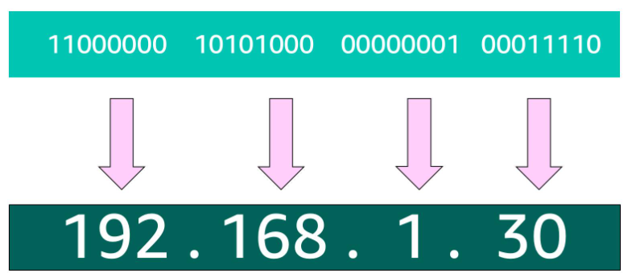

When working with a network we need to use **CIDR (Cluster Inter-Domain Routing)** Notation. This comes handy when we need to express IP addresses between ranges. This is a compresses way of specifying a range of IP addresses. It begins with a starting IP address and is separated by a forward slash followed by a number. The number at the end specifies how many of the bits of the UP address are fixed; the rest are flexible.

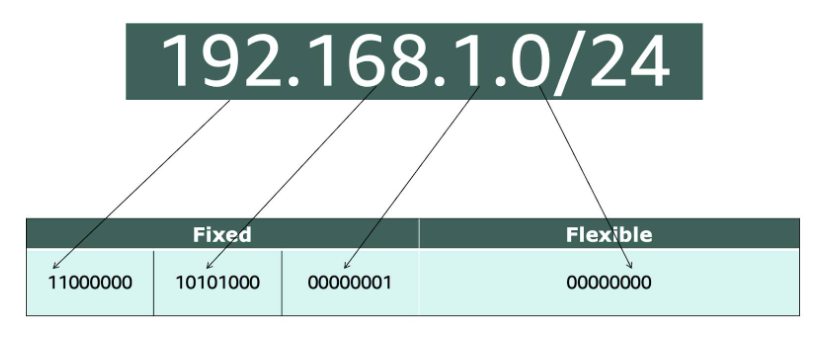

The example above has 24 bits fixed, and thus 8 bits flexible.

When working with networks in the AWS Cloud, you choose your network size by using CIDR notation. In AWS, the smallest IP range you can have is /28, which provides you 16 IP addresses. The largest IP range you can have is a /16, which provides you with 65,536 IP addresses.

## *Virtual Private Cloud (VPC)*

A **VPC** is an isolated network you create in AWS cloud, similar to a traditional network in a data center. When you create a VPC, you need to choose three main things.

1. The name of your VPC
2. A Region for your VPC to live in. Each VPC spans multiple Availability Zones within a Region you choose.
3. A IP range for our VPC in CIDR notation. This determines the size of your network. Each VPC can have up to four/16 IP ranges.

### Create a Subnet

After you create your VPC, you need to create subnets inside of this network. Think of subnets as smaller networks inside your base network—or virtual area networks (VLANs) in a traditional, on-premises network. In an on-premises network, the typical use case for subnets is to isolate or optimize network traffic. In AWS, subnets are used for high availability and providing different connectivity options for your resources.

When you create a subnet, you need to choose three settings.

1. The VPC you want your subnet to live in, in this case VPC (10.0.0.0/16).
2. The Availability Zone you want your subnet to live in, in this case AZ1.
3. A CIDR block for your subnet, which must be a subset of the VPC CIDR block, in this case 10.0.0.0/24.

When you launch an EC2 instance, you launch it inside a subnet, which will be located inside the Availability Zone you choose.

[figure not shown]

### Reserved IPs

For AWS to configure your VPC appropriately, AWS reserves five IP addresses in each subnet. These IP addresses are used for routing, Domain Name System (DNS), and network management.

For example, consider a VPC with the IP range 10.0.0.0/22. The VPC includes 1,024 total IP addresses. This is divided into four equal-sized subnets, each with a /24 IP range with 256 IP addresses. Out of each of those IP ranges, there are only 251 IP addresses that can be used because AWS reserves five.

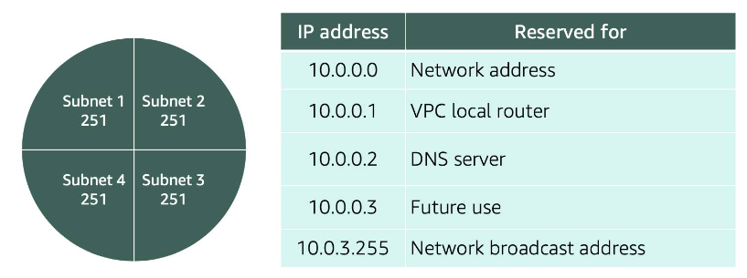

Since AWS reserves these five IP addresses, it can impact how you design your network. A common starting place for those who are new to the cloud is to create a VPC with a IP range of /16 and create subnets with a IP range of /24. This provides a large amount of IP addresses to work with at both the VPC and subnet level.

### Gateways

To enable internet connectivity for your VPC, you need to create an internet gateway. Think of this gateway as similar to a modem. Just as a modem connects your computer to the internet, the internet gateway connects your VPC to the internet. Unlike your modem at home, which sometimes goes down or offline, an internet gateway is highly available and scalable. After you create an internet gateway, you then need to attach it to your VPC.

A virtual private gateway allows you to connect your AWS VPC to another private network. Once you create and attach a VGW to a VPC, the gateway acts as anchor on the AWS side of the connection. On the other side of the connection, you’ll need to connect a customer gateway to the other private network. A customer gateway device is a physical device or software application on your side of the connection. Once you have both gateways, you can then establish an encrypted VPN connection between the two sides.

[output not shown]